# Task 1

Komissarov, Maksimov, Oblygina

12 March 2017

## Reading of data

```r
ts <- read.csv.zoo("training.csv",
                   index.column = 1,
                   FUN = as.Date, format = "%Y-%m-%d")

ts.monthly <- zooreg(ts, frequency = 12, start = c(1959, 1))

test <- zooreg(read.csv.zoo("testing.csv",
                     index.column = 1,
                     FUN = as.Date, format = "%Y-%m-%d"),
                     frequency = 12, start = c(1989, 1))
```

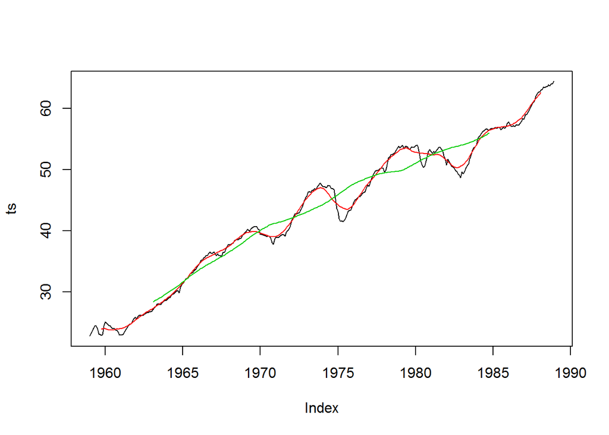

### Dickey-Fuller

```r
adf.test(ts, k = 0)
```

```
##
##  Augmented Dickey-Fuller Test
##
## data:  ts
## Dickey-Fuller = -1.4976, Lag order = 0, p-value = 0.7889
## alternative hypothesis: stationary
```

## Decomposition

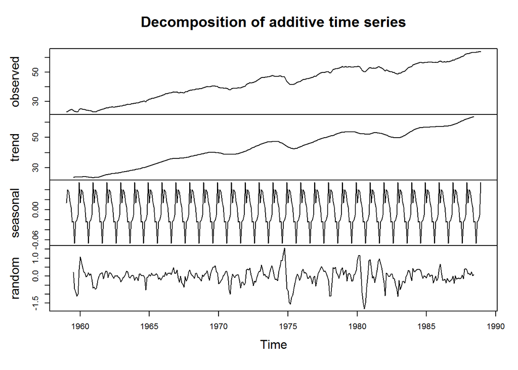

```r
ts.add <- decompose(as.ts(ts.monthly), type = "additive")
ts.mul <- decompose(as.ts(ts.monthly), type = "multiplicative")
plot(ts.add)
```

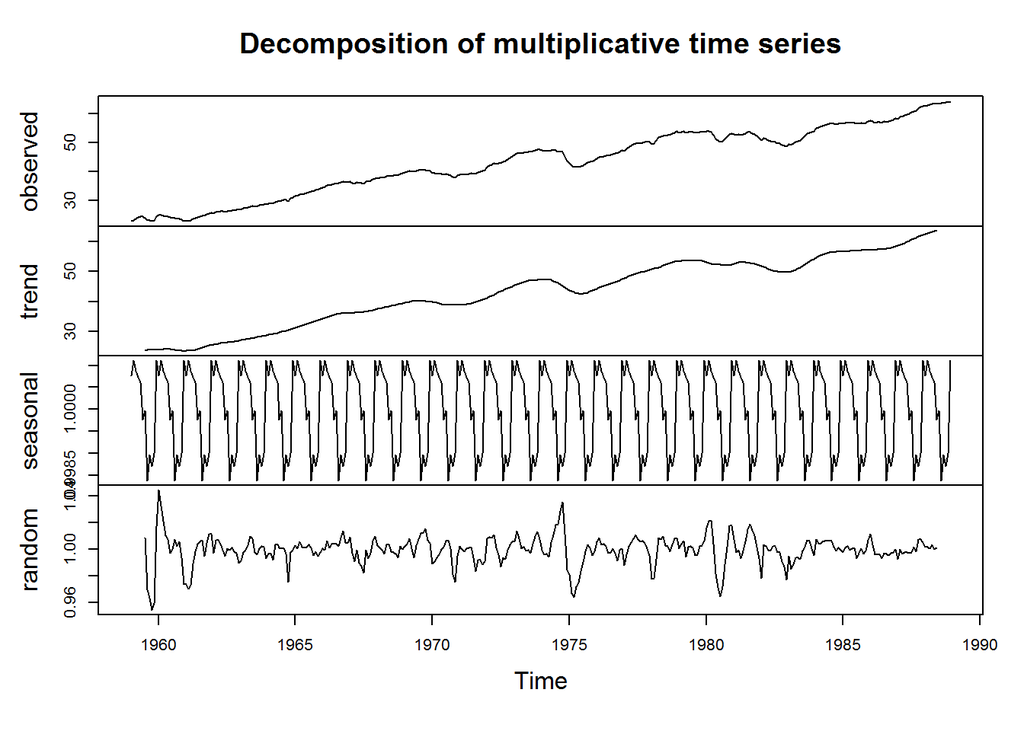

```r
plot(ts.mul)
```

```r
adf.test(na.remove(ts.mul$trend), k = 0)
```

```
##
##  Augmented Dickey-Fuller Test
##
## data:  na.remove(ts.mul$trend)
## Dickey-Fuller = -0.6874, Lag order = 0, p-value = 0.9711
## alternative hypothesis: stationary
```

```r
adf.test(na.remove(ts.mul$seasonal), k = 0)
```

```
##
##  Augmented Dickey-Fuller Test
##
## data:  na.remove(ts.mul$seasonal)
## Dickey-Fuller = -9.192, Lag order = 0, p-value = 0.01
## alternative hypothesis: stationary
```

## Order of integration

Для определения порядка интегрированности временного ряда достаточно проанализировать последовательно его разности.

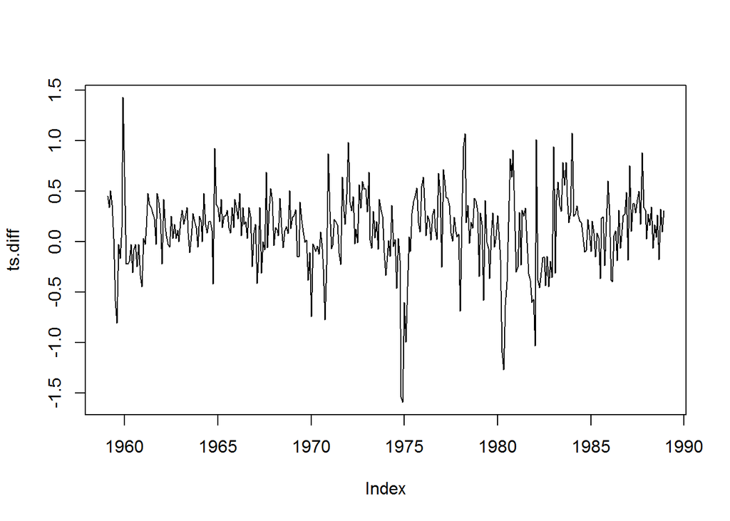

```r
ts.diff <- diff(ts, differences = 1)
plot(ts.diff)
```

```r
adf.test(ts.diff, k = 0)
```

```
##
##  Augmented Dickey-Fuller Test
##
## data:  ts.diff
## Dickey-Fuller = -12.2, Lag order = 0, p-value = 0.01
## alternative hypothesis: stationary
```

Согласно тесту Дики-Фуллера первая разность исходного ряда является стационарной, значит, порядок интегрированности равен 1.

## Correlation coefficients

Построим функции автокорреляции и частичной автокорреляции.

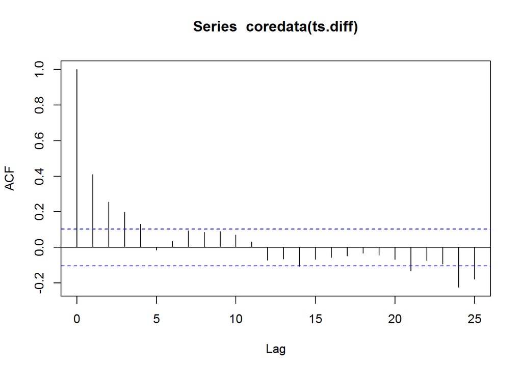

```r
acf(coredata(ts.diff))
```

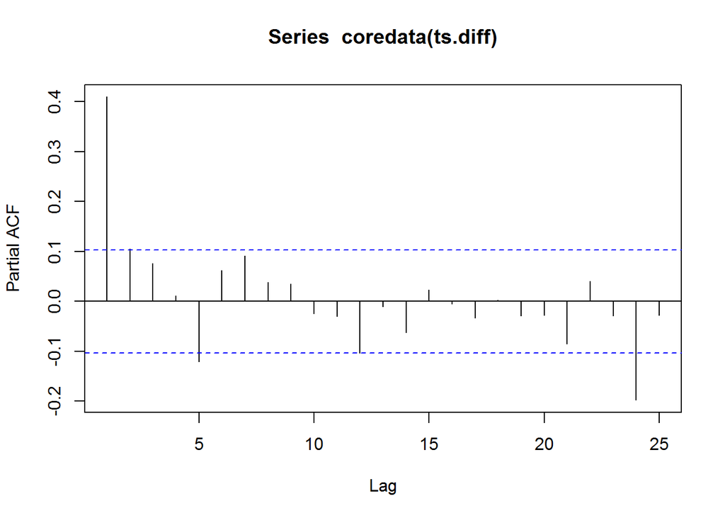

```r
pacf(coredata(ts.diff))
```

По наличию пиков можно предположить оптимальность моделей ARIMA(4, 1, 6) и ARIMA(3, 1, 5)

## ARIMA 1

Применим модель ARIMA(4, 1, 6)(1, 1, 2)[12]. Сделаем прогноз на 60 месяцев.

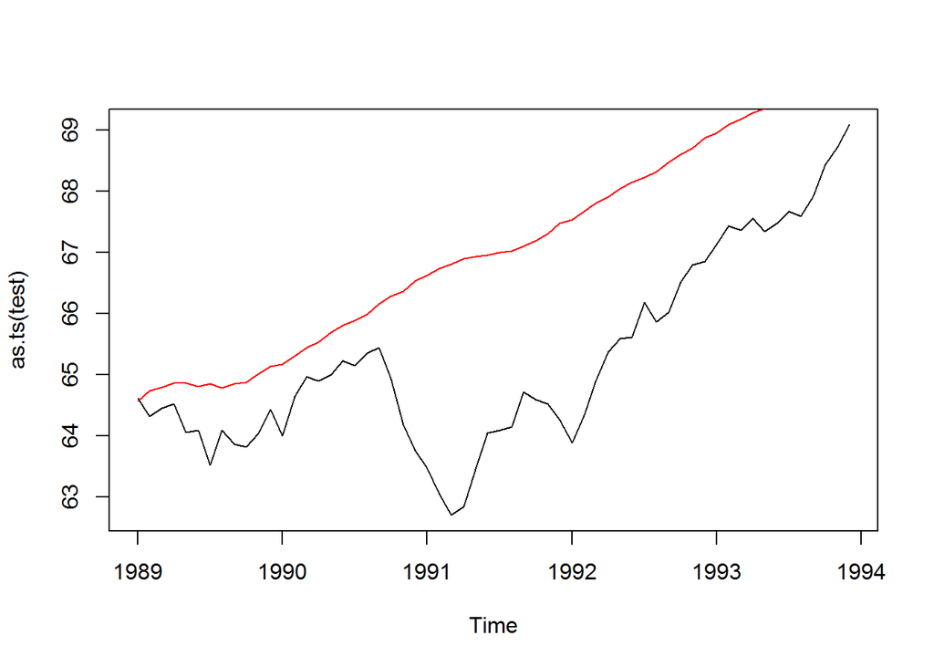

```r
ts.arima_1 = Arima(ts.monthly, order = c(4, 1, 6), seasonal = c(1, 1, 2))
for.arima_1 = forecast(ts.arima_1, h = 60)
plot(as.ts(test)); lines(for.arima_1$mean, col = 2)
```

Посчитаем r2-score.

```r
R2_Score(for.arima_1$mean, test)
```

```
## [1] -0.822411
```

## ARIMA 2

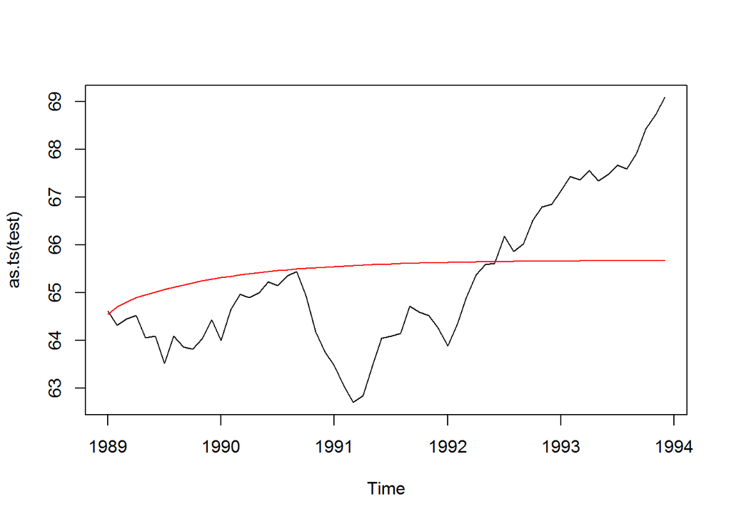

```r
ts.arima_2 = Arima(ts.monthly, order = c(3, 1, 5))
for.arima_2 = forecast(ts.arima_2, h = 60)
plot(as.ts(test)); lines(for.arima_2$mean, col = 2)
```

Посчитаем r2-score.

```r
R2_Score(for.arima_2$mean, test)
```

```
## [1] 0.1008945
```

## Neural Network

Применим нейронную сеть с 5 вложенными переменными. Сделаем прогноз на 60 месяцев.

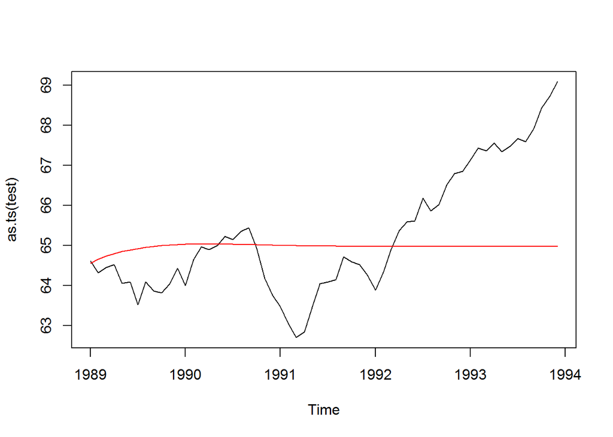

```r
ts.nn <- nnetar(as.ts(ts.monthly), p = 5)
for.nn = forecast(ts.nn, h = 60)
plot(as.ts(test)); lines(for.nn$mean, col = 2)
```

Посчитаем r2-score.

```r
R2_Score(for.nn$mean, test)
```

```
## [1] -0.02960753
```

## Linear Model

Применим простую линейную модель, предварительно декомпозирующую ряд на тренд и сезонность. Сделаем прогноз на 60 месяцев.

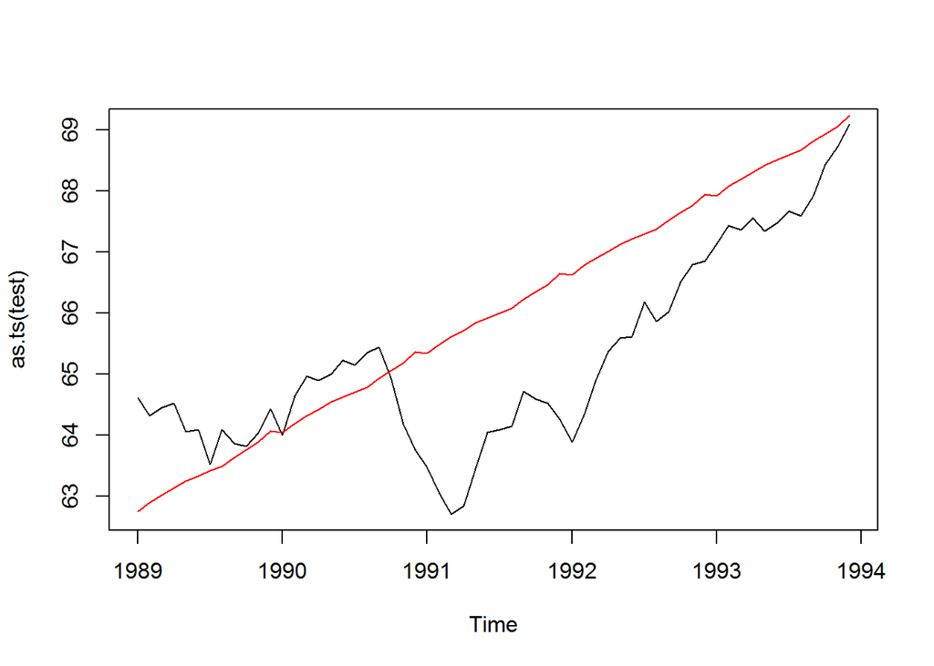

```r
ts.lm <- tslm(as.ts(ts.monthly) ~ trend + season)
for.lm = forecast(ts.lm, h = 60)
plot(as.ts(test)); lines(for.lm$mean, col = 2)
```

Посчитаем r2-score.

```r
R2_Score(for.lm$mean, test)
```

```
## [1] 0.1968743
```

## Conclusions

Обе версии ARIMA и нейронная сеть предсказывают результат на конец прогнозируемого срока хуже, чем линейная модель. ARIMA с сезональной частью не дает преимуществ, так как данные в seasonal на два порядка меньше остальных. Нейронная сеть и ARIMA предсказывают результаты начала срока лучше линейной модели. По результатам r2-score только линейная модель применима для тестовых данных. 60 месяцев, предоставленные к прогнозу по заданию, – неподходящий срок для сравнения моделей прогнозирования в данном случае.